# Practical Data Manipulation

# base & stats

You could get by only using the base and stats packages.

They are both powerful enough to do practically anything that you would ever need to do.

# The Downside

$Power + Flexibility = Complexity$

This was a common line for subsetting data:

```r
mtcars[which(mtcars$mpg >= mean(mtcars$mpg) & mtcars$cyl == 6), ]
```

```
##                 mpg cyl disp  hp drat    wt  qsec vs am gear carb
## Mazda RX4      21.0   6  160 110 3.90 2.620 16.46  0  1    4    4
## Mazda RX4 Wag  21.0   6  160 110 3.90 2.875 17.02  0  1    4    4
## Hornet 4 Drive 21.4   6  258 110 3.08 3.215 19.44  1  0    3    1
```

# Subsetting Variables

```r
varList = c("country",
            paste("iso", 2:3, sep = ""),
            grep(".*sp.*", colnames(who), value = TRUE))

newDat = who[, colnames(who) %in% varList]
```

# The Present

The base approach is not intuitive.

That is where dplyr enters the arena.

It is arguably one of the most popular R packages.

# The Grammar Of Data Manipulation

Intuitive names are the first improvement:

arrange| between| coalesce| distinct| filter| group_by| left_join| mutate| select| summarize| tally| top_n

Just given the function names, we can probably guess what each of these do.

# Translating Old To New

From this:

```r
mtcars[which(mtcars$mpg >= mean(mtcars$mpg) & mtcars$cyl == 6), ]
```

```
##                 mpg cyl disp  hp drat    wt  qsec vs am gear carb
## Mazda RX4      21.0   6  160 110 3.90 2.620 16.46  0  1    4    4
## Mazda RX4 Wag  21.0   6  160 110 3.90 2.875 17.02  0  1    4    4
## Hornet 4 Drive 21.4   6  258 110 3.08 3.215 19.44  1  0    3    1
```

To this:

```r
filter(mtcars, mpg >= mean(mpg) & cyl == 6)
```

```
##    mpg cyl disp  hp drat    wt  qsec vs am gear carb
## 1 21.0   6  160 110 3.90 2.620 16.46  0  1    4    4
## 2 21.0   6  160 110 3.90 2.875 17.02  0  1    4    4
## 3 21.4   6  258 110 3.08 3.215 19.44  1  0    3    1
```

# Wrangling Made Easy

```r
varList = c("country",
            paste("iso", 2:3, sep = ""),
            grep(".*sp.*", colnames(who),
                 value = TRUE))

newDat = who[, colnames(who) %in% varList]
```

```r
select(who, country, num_range("iso", 2:3), contains("sp"))
```

# SQL-like Joins

dplyr also provides several different joins.

left_join – x rows and all columns

right_join – y rows and all columns

inner_join – all matching rows and all columns

full_join – all rows and all columns

anti_join – return x rows where there are no y matches

# Joining Data

```r
df1 = data.frame(ticks = c("AAPL", "A", "BFG"),
                 revenue = c(10, 30, 50))

df2 = data.frame(tick = c("AAPL", "A", "N"),
                 expends = c(5, 15, 25))

inner_join(df1, df2, by = c("ticks" = "tick"))
```

```
##   ticks revenue expends
## 1  AAPL      10       5
## 2     A      30      15
```

# tidyr

Reshaping data can be a perilous excursion.

Plotting functions and many analyses need long data.

R has packages for reshaping (e.g., reshape2).

As good as those are, tidyr makes reshaping too easy.

It also has very clear functions:

gather, spread, unite, separate

# Wide To Long

```r
head(gather(mtcars, key = variable, value = value))
```

```
##   variable value
## 1      mpg  21.0
## 2      mpg  21.0
## 3      mpg  22.8
## 4      mpg  21.4
## 5      mpg  18.7
## 6      mpg  18.1
```

# Wide To Long – Grouped

```r
head(gather(mtcars, key = variable, value = value, -cyl))
```

```
##   cyl variable value
## 1   6      mpg  21.0
## 2   6      mpg  21.0
## 3   4      mpg  22.8
## 4   6      mpg  21.4
## 5   8      mpg  18.7
## 6   6      mpg  18.1
```

# Separate Columns

```r
(df = data.frame(executiveName = c("Jon Crutchfield", "Father Mark", "Roger Huang")))
```

```
##     executiveName
## 1 Jon Crutchfield
## 2     Father Mark
## 3     Roger Huang
```

```r
separate(df, executiveName, c("firstName", "lastName"))
```

```
##   firstName    lastName
## 1       Jon Crutchfield
## 2    Father        Mark
## 3     Roger       Huang
```

# magrittr

> The famous pipe. How people reproached me for it! And yet, could you stuff my pipe? No, it’s just a representation, is it not? So if I had written on my picture ‘This is a pipe’, I’d have been lying!

# Pipes

The magrittr package contains a number of different pipes.

%$%| %<>%| %>%| %T>%

- The most popular one is likely %>%.
- It is functionally equivalent to the Unix |

# Aliases

R has some mysterious functions.

magrittr gives names to some of these rather archiac functions.

`[[` = extract2

# Action Sequence

```r
`[[`(mtcars, 1)
```

```
##  [1] 21.0 21.0 22.8 21.4 18.7 18.1 14.3 24.4 22.8 19.2 17.8 16.4 17.3 15.2
## [15] 10.4 10.4 14.7 32.4 30.4 33.9 21.5 15.5 15.2 13.3 19.2 27.3 26.0 30.4
## [29] 15.8 19.7 15.0 21.4
```

```r
extract2(mtcars, 1)
```

```
##  [1] 21.0 21.0 22.8 21.4 18.7 18.1 14.3 24.4 22.8 19.2 17.8 16.4 17.3 15.2
## [15] 10.4 10.4 14.7 32.4 30.4 33.9 21.5 15.5 15.2 13.3 19.2 27.3 26.0 30.4
## [29] 15.8 19.7 15.0 21.4
```

# Can’t Stop The Flow

Using these three packages together gives us ultimate power.

We can pipe functions together until we get what we need.

- You can also pipe to other functions (e.g., lm).

# Days Of Yore

I want years greater than 2000, only columns with “sn”, averaged by country, and taken from wide to long.

```r
who1 = who[who$year > 2000, grep("country|.*sn.*", colnames(who))]

who1 = na.omit(who1)

colList = list(grep("*sn.*", colnames(who1), value = TRUE))

res = lapply(colList,
             function(x) aggregate(who1[x], by = list(who1$country), FUN = mean))
```

# And It Don’t Stop…

```r
res = as.data.frame(res)

row.names(res) = res$Group.1

res$Group.1 = NULL

res = reshape(res, idvar = "country", ids = row.names(res),
              times = names(res), timevar = "var",
              varying = list(1:14),
              direction = "long")

head(res)
```

```
##                                         var new_sn_m014
## Albania.new_sn_m014             new_sn_m014      7.0000
## American Samoa.new_sn_m014      new_sn_m014      0.0000
## Andorra.new_sn_m014             new_sn_m014      0.0000
## Anguilla.new_sn_m014            new_sn_m014      0.0000
## Antigua and Barbuda.new_sn_m014 new_sn_m014      0.0000
## Argentina.new_sn_m014           new_sn_m014    350.8571
##                                             country
## Albania.new_sn_m014                         Albania
## American Samoa.new_sn_m014           American Samoa
## Andorra.new_sn_m014                         Andorra
## Anguilla.new_sn_m014                       Anguilla
## Antigua and Barbuda.new_sn_m014 Antigua and Barbuda
## Argentina.new_sn_m014                     Argentina
```

# There Has To Be A Better Way

```r
who1 = who %>%
  filter(year > 2000) %>%
  select(country, contains("sn")) %>%
  na.omit() %>%
  group_by(country) %>%
  summarize_all(funs(mean(., na.rm = TRUE))) %>%
  gather(key = variable, value = value, -country)

head(who1)
```

```
## # A tibble: 6 × 3
##               country    variable    value
##                 <chr>       <chr>    <dbl>
## 1             Albania new_sn_m014   7.0000
## 2      American Samoa new_sn_m014   0.0000
## 3             Andorra new_sn_m014   0.0000
## 4            Anguilla new_sn_m014   0.0000
## 5 Antigua and Barbuda new_sn_m014   0.0000
## 6           Argentina new_sn_m014 350.8571
```

# data.table

The data.table package is a pretty far departure from dplyr.

Everything works with *i*, *j*, *k* indexing.

$$data.table(i, j, k) = data.table[which, what, by]$$

While dplyr is clear and concise, data.table is slightly confusing.

What it lacks in elegance, it makes up for in speed!

# That Is Fast

```r
whoDT = data.table(who, key = "country")

dtTest = whoDT[, mean(new_sp_m014, na.rm = TRUE), by = country]
```

```r
dplyrTest = who %>%
  group_by(country) %>%
  summarize(mean(new_sp_m014, na.rm = TRUE))
```

```r
microbenchmark::microbenchmark(who %>%
  group_by(country) %>%
  summarize(mean(new_sp_m014, na.rm = TRUE)),
  whoDT[, mean(new_sp_m014, na.rm = TRUE), by = country],
  unit = "s", times = 500)
```

```
## Unit: seconds
##                                                                      expr
##  who %>% group_by(country) %>% summarize(mean(new_sp_m014, na.rm = TRUE))
##                    whoDT[, mean(new_sp_m014, na.rm = TRUE), by = country]
##          min           lq         mean       median          uq
##  0.004150377 0.0046395400 0.0057052357 0.0053575105 0.006462634
##  0.000493370 0.0006326375 0.0008423986 0.0007740085 0.000954139
##          max neval cld
##  0.010680166   500   b
##  0.003660012   500  a
```

# Convenience Functions

There are a few different convenience functions within data.table.

These two are incredibly helpful.

.I = seq_len(nrow(x))

.GRP = group counter

# Chaining Indices

Just like the pipes we previously saw, data.table lets us continuously chain statements together.

```r
whoDT[, mean(new_sp_m014, na.rm = TRUE), by = country][, log(V1), by = country]
```

```
##                        country        V1
##   1:               Afghanistan  4.868015
##   2:                   Albania  0.000000
##   3:                   Algeria  4.532599
##   4:            American Samoa -1.386294
##   5:                   Andorra      -Inf
##  ---
## 215: Wallis and Futuna Islands      -Inf
## 216:  West Bank and Gaza Strip -1.203973
## 217:                     Yemen  4.180352
## 218:                    Zambia  5.508713
## 219:                  Zimbabwe  5.068332
```

It can get ugly (and fast)!

# A Real Example

```r
mrktingName = mrktingName[, c("Ticker.Symbol", "Fiscal.Year",
                              "howLongPerson", "personID") :=
                            list(Ticker.Symbol, Fiscal.Year,
                                 seq(.N), .GRP),
                          by = list(name)]
[, numSeq := seq(min(Fiscal.Year),
                 max(Fiscal.Year)), by = list(personID)]
[, runningTotal := ifelse(Fiscal.Year == numSeq, seq(.N), 1L),
by = list(Ticker.Symbol, personID)]
```

# What Do R And Neapolitan Ice Cream Have In Common?

You can enjoy all flavors at once!

# And It Is Just As Tasty…

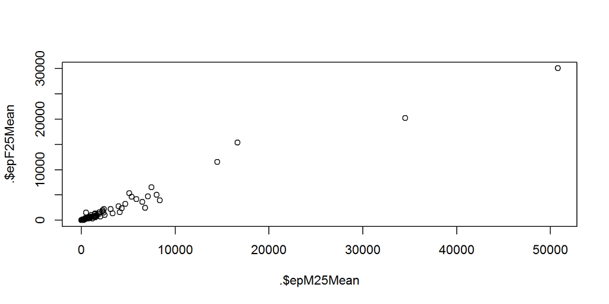

```
## data frame with 0 columns and 6892 rows
```

```r
who %>%
  select(country, contains("sp")) %>%
  data.table(key = "country") %>%
  .[, c("epM25Mean", "epF25Mean") :=
      list(mean(new_sp_m2534, na.rm = TRUE), mean(new_sp_f2534, na.rm = TRUE)),
    by = country] %>%
  filter(epM25Mean > 0 & epF25Mean > 0) %>%
  .[, plot(.$epM25Mean, .$epF25Mean)]
```

# stringr

stringr eases string pain.

Unless you have a need to use regex regularly, it can be tricky.

stringr has a variety of functions to replace grep and gsub.

# Audience Participation Time!

What would the following line do?

^\\s+|\\s+$

# Trimming Strings

```r
x = " Happy Halloween!   "

gsub("^\\s+|\\s+$", "", x)
```

```
## [1] "Happy Halloween!"
```

```r
str_trim(x)
```

```
## [1] "Happy Halloween!"
```

# Counting Characters

```r
people = c("Seth Berry", "George Jiang", NA, "Andres Martinez")
```

```r
nchar(people)
```

```
## [1] 10 12 NA 15
```

```r
str_count(people)
```

```
## [1] 10 12 NA 15
```

# A Huge Thanks To This Bloke

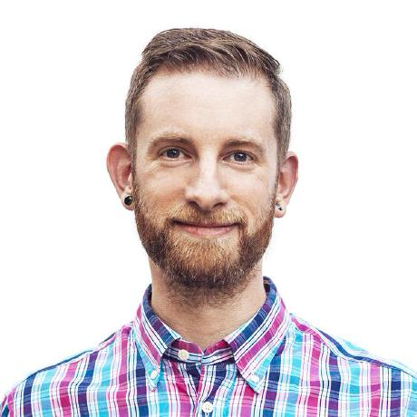

# And A Huge Thanks To You All